# Fit models

Author

Max Lindmark & Francesca Vitale

Published

2026-10-01

```r
# Load libraries
library(tidyverse)
library(ggaqua)
library(tidylog)
library(sdmTMB)
library(patchwork)
library(viridis)
library(RColorBrewer)
library(modelr)
library(ggtext)
library(tictoc)
library(ggsidekick); theme_set(theme_sleek())

home <- here::here()

# Load all custom functions in R/function

for(fun in list.files(paste0(home, "/R/functions"))){
  source(paste(home, "R/functions", fun, sep = "/"))
}
```

## Read and prepare data

Read data & scale variables. Note we have convert data from catch per hour to catch per area in this [script](https://github.com/maxlindmark/greater-weever/blob/main/R/prepare-data/00-prep-data.qmd), to make better use of the `get_index` function in sdmTMB.

```r
d <- readr::read_csv(paste0(home, "/data/clean/trawl.csv")) |>
  filter(depth > 0) |>
  drop_na(temp) |>
  filter(quarter %in% c(1, 3)) |>
  mutate(temp_sc = as.numeric(scale(temp)),
         depth = log(depth),
         depth_sc = as.numeric(scale(depth)),
         depth_sq = depth_sc*depth_sc,
         quarter_f = as.factor(quarter),
         year_f = as.factor(year))

# Read prediction grid
pred_grid <- readr::read_csv(paste0(home, "/data/clean/pred_grid.csv")) |>
  drop_na(temp) |>
  # Shallower than this there are no hauls, so predictions are pure extrapolation of the depth effect
  filter(depth >= 10) |>
  mutate(temp_sc = as.numeric(scale(temp)),
         depth = log(depth),
         depth_sc = (depth - mean(d$depth)) / sd(d$depth),
         depth_sq = depth_sc*depth_sc,
         quarter_f = as.factor(quarter),
         year_f = as.factor(year))
```

Fit models. Initial exploration suggest a delta_gamma model [Poisson-link delta gamma](https://pbs-assess.github.io/sdmTMB/articles/web_only/poisson-link.html). Note that we need to put an ar1 on the intercept. Typically we model year as a factor to get independent estimates. However in this case, we are missing q3 data in year 2000. This somehow makes the yearf estimate for 2000 very high, because there’s nothing to inform i, aand q1 in 2000 is one of the largest years. Allowing the year effect to evolve through time doesn’t mean it estimates separate year effects for each quarter, just that it gets a memory. In theory we could go for a rw0 on time rather than ar1, because correlation is near one, but i get worse diagnistics then.

The big year_f2000 comes from the model trying to fit the unusually large quarter-1 observations in 2000, and because the fixed-effects model multiplies year and quarter effects, that large year multiplier then amplifies the global quarter-3 multiplier when you ask the model for a 2000×Q3 prediction. The AR1/time-varying model doesn’t blow up because it partially pools (shrinks) the 2000 year effect toward neighboring years, so the amplification is tamed.

Regarding fields: Interpolation of 1–2 missing years: AR1 usually preferable — gives stable interpolation. Long-term drifting patterns (e.g., species range shift): RW may be more realistic. Forecasting beyond observed years: AR1 shrinks forecasts back toward the long-run mean field. RW allows forecasts to wander off (with big uncertainty).

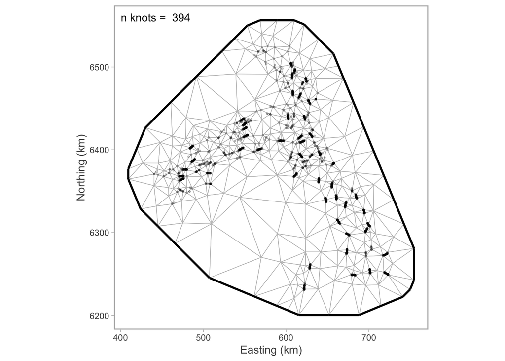

```r
mesh <- make_mesh(d,
                  xy_cols = c("X", "Y"),
                  cutoff = 4)

ggplot() +
  inlabru::gg(mesh$mesh) +
  coord_fixed() +
  geom_point(aes(X, Y), data = d, alpha = 0.2, size = 0.5) +
  annotate("text", -Inf, Inf, label = paste("n knots = ", mesh$mesh$n), hjust = -0.1, vjust = 2) +
  labs(x = "Easting (km)", y = "Northing (km)")
```

Fit AIC-selected model

```r
# Spatiotemporal ar1 and squared depth for binomial and linear for gamma, allow spatial fields to vary with quarter?
tic()
m5 <- sdmTMB(
  formula = list(density ~ depth_sc + depth_sq + temp_sc + quarter_f,
                 density ~ depth_sc + temp_sc + quarter_f),
  data = d,
  mesh = mesh,
  family = delta_gamma(type = "poisson-link"),
  time_varying = ~1,
  time_varying_type = "ar1",
  spatiotemporal = list("off", "ar1"),
  spatial = "off",
  spatial_varying = ~ 0 + quarter_f,
  time = "year")
toc()
```

```
103.271 sec elapsed
```

```r
tidy(m5, effects = "ran_pars")
```

```
# A tibble: 4 × 6
  model term     estimate std.error conf.low conf.high
  <dbl> <chr>       <dbl>     <dbl>    <dbl>     <dbl>
1     1 range      59.3     14.0      37.4      94.1
2     1 sigma_Z     1.50     0.281     1.04      2.16
3     1 sigma_Z     1.41     0.244     1.00      1.98
4     1 rho_time    0.968    0.0373    0.719     0.997
```

```r
sanity(m5)
```

```
✔ Non-linear minimizer suggests successful convergence
```

```
✔ Hessian matrix is positive definite
```

```
✔ No extreme or very small eigenvalues detected
```

```
✔ No gradients with respect to fixed effects are >= 0.001
```

```
✔ No fixed-effect standard errors are NA
```

```
✔ No standard errors look unreasonably large
```

```
✔ No sigma parameters are < 0.01
```

```
✔ No sigma parameters are > 100
```

```
✔ Range parameters don't look unreasonably large
```

### Get index over time

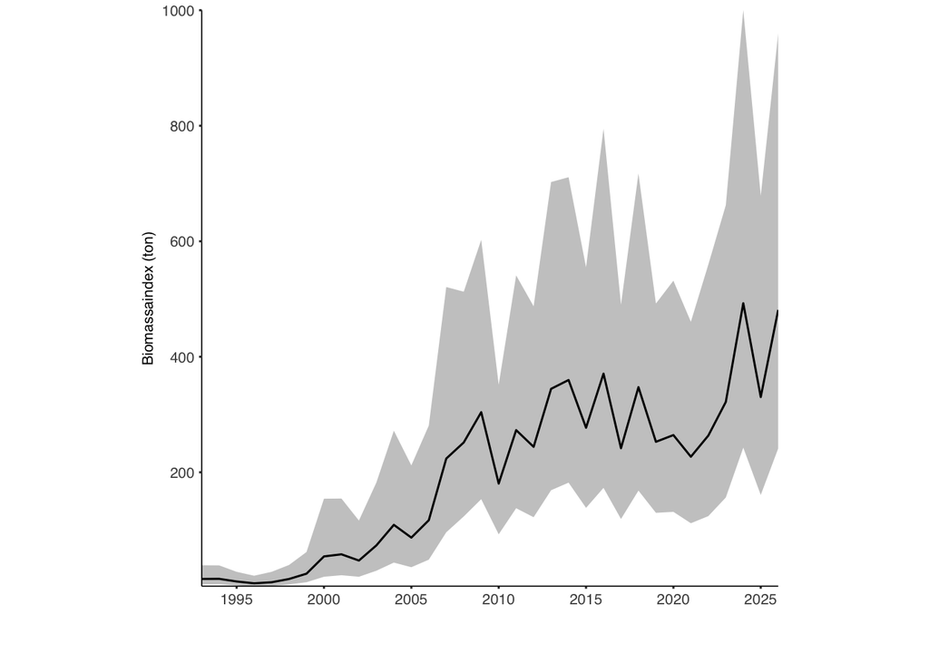

```r
pred_tmb_q3 <- predict(
  m5,
  newdata = pred_grid |> filter(quarter == 3),
  return_tmb_object = TRUE)

index_q3 <- get_index(pred_tmb_q3, area = 9, bias_correct = TRUE, level = 0.95)

index_q3 |>
  ggplot(aes(year, est/1000)) +
  theme_aqua() +
  scale_x_continuous(expand = c(0, 0), breaks = scales::pretty_breaks(n = 6)) +
  scale_y_continuous(expand = c(0, 0), breaks = scales::pretty_breaks(n = 5)) +
  geom_ribbon(aes(ymin = lwr/1000, ymax = upr/1000), alpha = 0.3, color = NA) +
  geom_line() +
  labs(x = "", y = "Biomassaindex (ton)")
```

```r
ggsave(paste0(home, "/figures/fiskbarometern/Fig_3_maxlindmark.png"),
       dpi = 300, width = 8, height = 8, units = "cm")
```